# Basic_visualization_DZ2

Saldaeva V

2024-10-17

# Загрузка данных

```r
hogwarts <- read_csv("/Users/Алексей/Desktop/mag/statistics/biostatistics/Basic_visualization/визуализация данных/data/hogwarts_2024.csv")
hogwarts |> head()
```

```
## # A tibble: 6 × 60
##      id house    course sex   wandCore bloodStatus result Defence against the …¹
##   <dbl> <chr>     <dbl> <chr> <chr>    <chr>        <dbl>                  <dbl>
## 1     1 Ravencl…      4 fema… unicorn… half-blood      94                     73
## 2     2 Hufflep…      5 male  phoenix… half-blood      33                     38
## 3     3 Ravencl…      4 fema… dragon … half-blood     137                     52
## 4     4 Hufflep…      2 male  phoenix… half-blood      27                     50
## 5     5 Hufflep…      2 fema… phoenix… half-blood      67                     47
## 6     6 Gryffin…      6 male  phoenix… muggle-born    126                     44
## # ℹ abbreviated name: ¹`Defence against the dark arts exam`
## # ℹ 52 more variables: `Flying exam` <dbl>, `Astronomy exam` <dbl>,
## #   `Herbology exam` <dbl>, `Divinations exam` <dbl>, `Charms exam` <dbl>,
## #   `History of magic exam` <dbl>, `Arithmancy exam` <dbl>,
## #   `Care of magical creatures exam` <dbl>, `Muggle studies exam` <dbl>,
## #   `Study of ancient runes exam` <dbl>, `Transfiguration exam` <dbl>,
## #   `Potions exam` <dbl>, week_1 <dbl>, week_2 <dbl>, week_3 <dbl>, …
```

## Проверка структуры данных

```r
hogwarts |> glimpse()
```

```
## Rows: 560
## Columns: 60
## $ id                                   <dbl> 1, 2, 3, 4, 5, 6, 7, 8, 9, 10, 11…
## $ house                                <chr> "Ravenclaw", "Hufflepuff", "Raven…
## $ course                               <dbl> 4, 5, 4, 2, 2, 6, 7, 5, 2, 3, 7, …
## $ sex                                  <chr> "female", "male", "female", "male…
## $ wandCore                             <chr> "unicorn hair", "phoenix feather"…
## $ bloodStatus                          <chr> "half-blood", "half-blood", "half…
## $ result                               <dbl> 94, 33, 137, 27, 67, 126, 63, 7, …
## $ `Defence against the dark arts exam` <dbl> 73, 38, 52, 50, 47, 44, 51, 47, 2…
## $ `Flying exam`                        <dbl> 33, 36, 73, 42, 41, 52, 34, 34, 2…
## $ `Astronomy exam`                     <dbl> 57, 45, 66, 49, 57, 59, 58, 37, 5…
## $ `Herbology exam`                     <dbl> 73, 50, 62, 39, 38, 46, 59, 23, 2…
## $ `Divinations exam`                   <dbl> 66, 54, 72, 42, 47, 49, 42, 38, 1…
## $ `Charms exam`                        <dbl> 60, 70, 77, 46, 35, 55, 86, 20, 4…
```

[output cut: 47 more lines]

```r
# Changing some variables type to factors
hogwarts <- hogwarts |> mutate(
  across(c(house, course, sex, wandCore, bloodStatus), ~ as.factor(.x))
)
```

```r
theme_custom <- theme(
    panel.background = element_rect(fill = "white"),
    plot.title = element_text(size = 27, hjust = 0.3),
    plot.subtitle = element_text(size = 25, hjust = 0.5),
    strip.text = element_text(size = 20),
    axis.text = element_text(size = 20),
    axis.title = element_text(size = 25),
    legend.title = element_text(size = 25),
    legend.text = element_text(size = 20)
  )

# А еще мы создаем функцию для стандартной ошибки среднего
se <- function(x){
  sd(x, na.rm=TRUE)/sqrt(length(x))
}
se <- function(x){
  sd(x, na.rm=TRUE)/sqrt(length(x))
}
```

#Диаграммы рассеяния (скаттерплоты) ## Задание №1

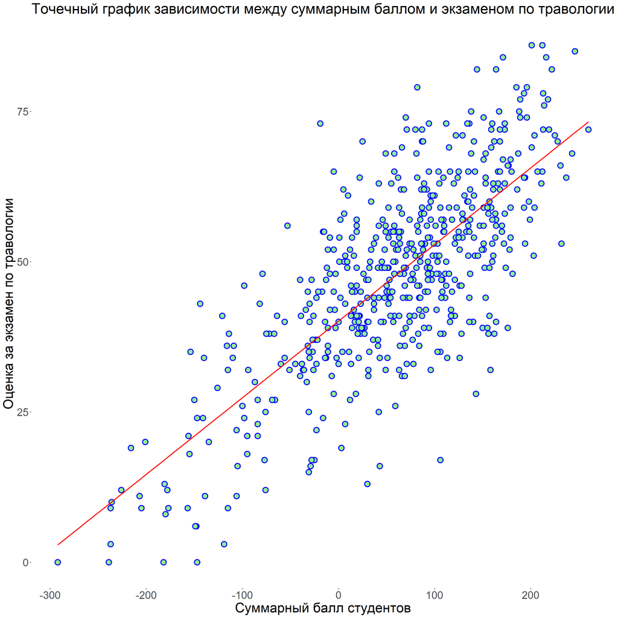

```r
 hogwarts |>
  ggplot() +
  geom_point(aes(x = `result`,
                 y = `Herbology exam`),
             size = 4,
             shape = 21,
             colour = "blue",
             fill = "lightgreen",
             stroke = 1.5) + #толщина контура
  geom_smooth(aes(x = `result`,
                  y = `Herbology exam`),
              se = FALSE,
              method = "lm",
              colour = "red") +
  theme_custom +
  labs(x = "Суммарный балл студентов",
       y = "Оценка за экзамен по травологии",
       title = "Точечный график зависимости между суммарным баллом и экзаменом по травологии") + theme_custom
```

Интерпретация: сушествует прямая зависимость между суммарным баллом студента за год и оценкой за экзамен по травологии. Чем выше суммарный балл, тем выше оценка за экзамен по травологии.

## Задание №2

### Первый вариант (извините, за разные варианты, задание немного не поняла и хотелось потренироваться). Верный, скорее всего 4 вариант, но не уверенна.

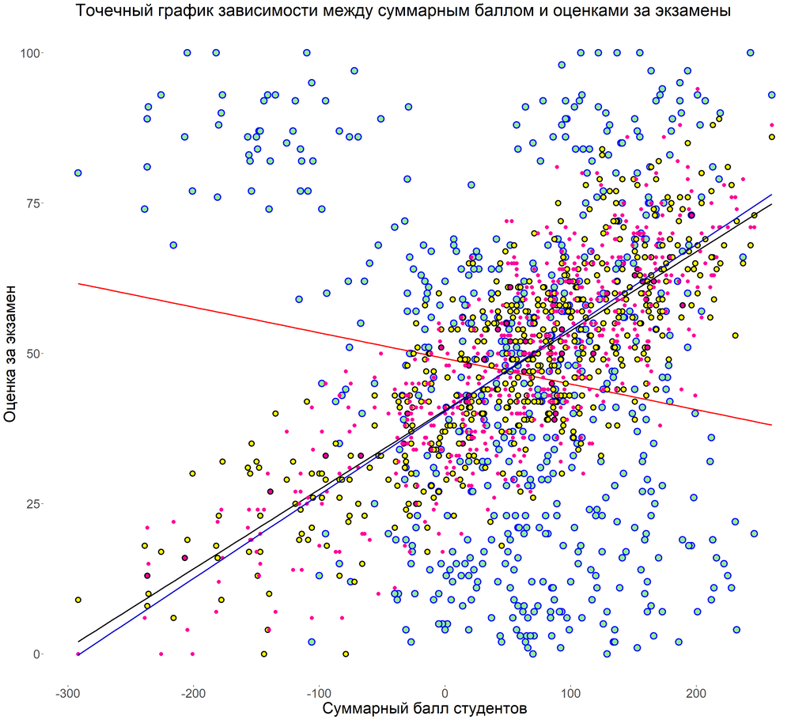

```r
 hogwarts |>
  ggplot() +
  geom_point(aes(x = `result`,
                 y = `Potions exam`), #Экзамен по зельеваренью
             size = 4,
             shape = 21,
             colour = "blue",
             fill = "lightgreen",
             stroke = 1.5) + #толщина контура
  geom_smooth(aes(x = `result`,
                  y = `Potions exam`),
              se = FALSE,
              method = "lm",
              colour = "red") +
  geom_point(aes(x = `result`,
                 y = `Divinations exam`),#прорицания
             size = 3,
             shape = 21,
             colour = "black",
             fill = "yellow",
             stroke = 1.5) + #толщина контура
  geom_smooth(aes(x = `result`,
                  y = `Divinations exam`),
              se = FALSE,
              method = "lm",
              colour = "black") +
  geom_point(aes(x = `result`,
                 y = `Muggle studies exam`), # экзамен по магловедению
             size = 2,
             shape = 16,
             colour = "#FF0099",
             stroke = 1.5) + #толщина контура
  geom_smooth(aes(x = `result`,
                  y = `Muggle studies exam`),
              se = FALSE,
              method = "lm",
              colour = "#0000CC") +

  theme_custom +
  labs(x = "Суммарный балл студентов",
       y = "Оценка за экзамен",
       title = "Точечный график зависимости между суммарным баллом и оценками за экзамены") + theme_custom
```

```r
hogwarts %>%
  mutate(course = as.factor(course))
```

```
## # A tibble: 560 × 60
##       id house   course sex   wandCore bloodStatus result Defence against the …¹
##    <dbl> <fct>   <fct>  <fct> <fct>    <fct>        <dbl>                  <dbl>
##  1     1 Ravenc… 4      fema… unicorn… half-blood      94                     73
##  2     2 Huffle… 5      male  phoenix… half-blood      33                     38
##  3     3 Ravenc… 4      fema… dragon … half-blood     137                     52
##  4     4 Huffle… 2      male  phoenix… half-blood      27                     50
##  5     5 Huffle… 2      fema… phoenix… half-blood      67                     47
##  6     6 Gryffi… 6      male  phoenix… muggle-born    126                     44
##  7     7 Huffle… 7      fema… unicorn… half-blood      63                     51
##  8     8 Huffle… 5      fema… phoenix… half-blood       7                     47
##  9     9 Gryffi… 2      male  unicorn… half-blood     -84                     22
## 10    10 Slythe… 3      fema… dragon … pure-blood     171                     57
## # ℹ 550 more rows
## # ℹ abbreviated name: ¹`Defence against the dark arts exam`
## # ℹ 52 more variables: `Flying exam` <dbl>, `Astronomy exam` <dbl>,
## #   `Herbology exam` <dbl>, `Divinations exam` <dbl>, `Charms exam` <dbl>,
## #   `History of magic exam` <dbl>, `Arithmancy exam` <dbl>,
## #   `Care of magical creatures exam` <dbl>, `Muggle studies exam` <dbl>,
## #   `Study of ancient runes exam` <dbl>, `Transfiguration exam` <dbl>, …
```

### Второй вариант

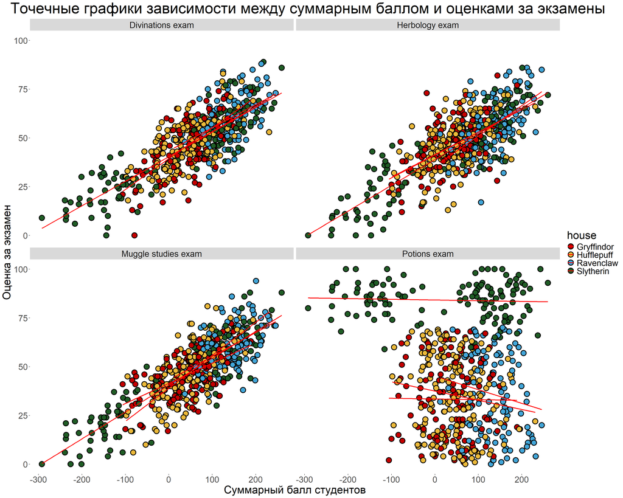

```r
long_hogwarts <- hogwarts %>%
  select(result, `Herbology exam`, `Muggle studies exam`, `Divinations exam`, `Potions exam`, house) %>%
  pivot_longer(cols = c(`Herbology exam`, `Muggle studies exam`, `Divinations exam`, `Potions exam`),
               names_to = "exam", values_to = "score")

scatterPlots <- long_hogwarts |>
  ggplot(aes(x = result, y = score, fill = house)) +
  geom_point(size = 5, shape = 21, stroke = 1.5, colour = "black") +
  geom_smooth(se = FALSE, method = "lm", colour = "red") +
  scale_fill_manual(values = c("Gryffindor" = "#C50000",
                                "Hufflepuff" = "#ECB939",
                                "Ravenclaw" = "#41A6D9",
                                "Slytherin" = "#1F5D25")) +
  theme_custom +
  labs(x = "Суммарный балл студентов",
       y = "Оценка за экзамен",
       title = "Точечные графики зависимости между суммарным баллом и оценками за экзамены") +
  theme(plot.title = element_text(size = 35)) +
  facet_wrap(~ exam)

scatterPlots
```

### Третий вариант

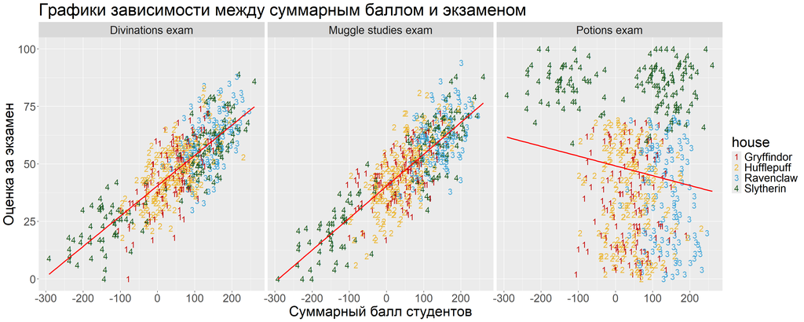

```r
hogwarts_long <- hogwarts %>%
  pivot_longer(cols = c(`Muggle studies exam`, `Divinations exam`, `Potions exam`),
               names_to = "exam",
               values_to = "score")

hogwarts_long |>
  ggplot() +
  geom_point(aes(x = result,
                 y = score,
                 shape = house,
                 colour = house),
             size = 5) +
  geom_smooth(aes(x = result, y = score, colour = house),
              se = FALSE,
              method = "lm",
              colour = "red") +
  scale_color_manual(values = c("Gryffindor" = "#C50000",
                                 "Hufflepuff" = "#ECB939",
                                 "Ravenclaw" = "#41A6D9",
                                 "Slytherin" = "#1F5D25")) +
  scale_shape_manual(values = c(Gryffindor = 49, Hufflepuff = 50, Ravenclaw = 51, Slytherin = 52)) +

  labs(x = "Суммарный балл студентов",
       y = "Оценка за экзамен",
       title = "Графики зависимости между суммарным баллом и экзаменом") +
  theme(plot.title = element_text(size = 30),
        legend.title = element_text(size = 25),
        legend.text = element_text(size = 20),
        strip.text = element_text(size = 20),
        axis.text = element_text(size = 20),
        axis.title = element_text(size = 25)) +
  facet_wrap(~ exam)
```

### Четвертый вариант (самый большой)

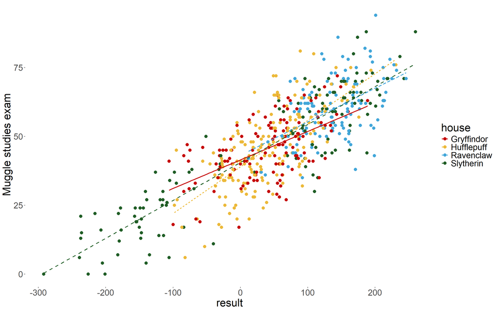

```r
scatterShapeCourse_1 <- hogwarts |>
  mutate(course = as.factor(course)) |>
  ggplot()+
  geom_point(aes(x = `result`,
                 y = `Muggle studies exam`,
                 shape = house,
                 colour = house),
             size = 5)+
  scale_color_manual(values = c("Gryffindor" = "#C50000",
                                 "Hufflepuff" = "#ECB939",
                                 "Ravenclaw" = "#41A6D9",
                                 "Slytherin" = "#1F5D25")) +
  scale_shape_manual(values = rep(20, 4))+
  scale_y_continuous(position = "left")+
  theme_custom
scatterShapeCourse_1+
  geom_smooth(aes(x = `result`,
                  y = `Muggle studies exam`,
                  colour = house,
                  linetype = house),
              se = FALSE,
              method = "lm")
```

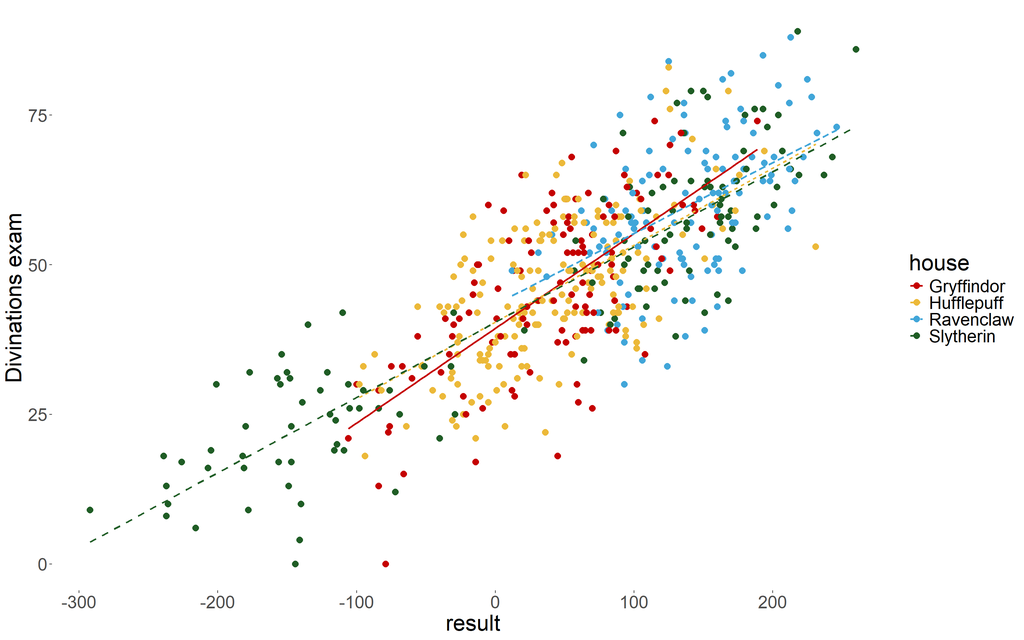

```r
scatterShapeCourse_2 <- hogwarts |>
  ggplot()+
  geom_point(aes(x = `result`,
                 y = `Divinations exam`,
                 shape = house,
                 colour = house),
             size = 5)+
  scale_color_manual(values = c("Gryffindor" = "#C50000",
                                 "Hufflepuff" = "#ECB939",
                                 "Ravenclaw" = "#41A6D9",
                                 "Slytherin" = "#1F5D25")) +
  scale_shape_manual(values = rep(20, 4))+
  scale_y_continuous(position = "left")+
  theme_custom
scatterShapeCourse_2+
  geom_smooth(aes(x = `result`,
                  y = `Divinations exam`,
                  colour = house,
                  linetype = house),
              se = FALSE,
              method = "lm")
```

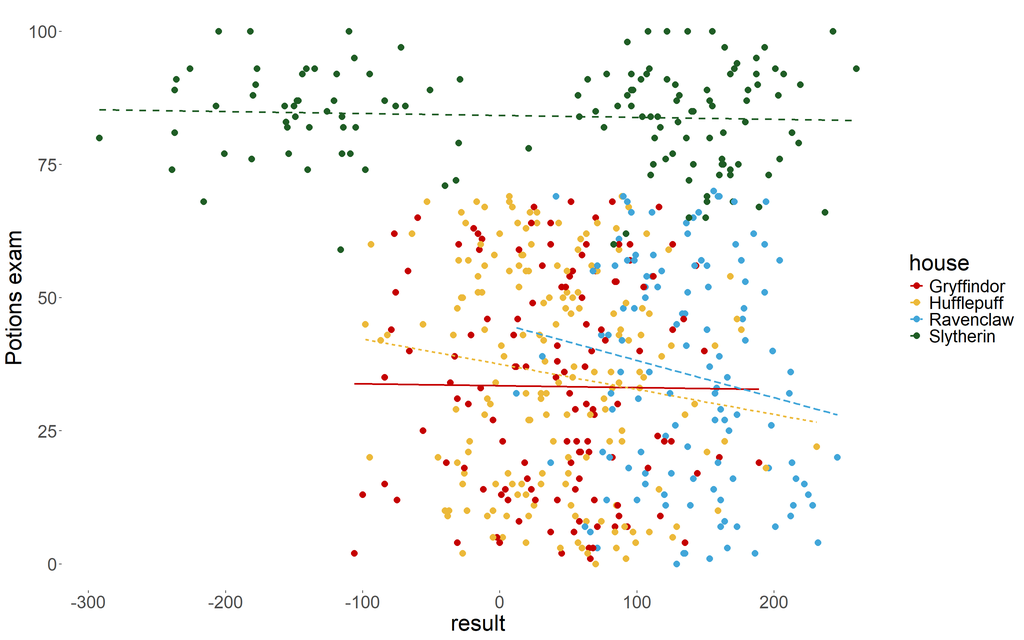

```r
scatterShapeCourse_3 <- hogwarts |>
  ggplot()+
  geom_point(aes(x = `result`,
                 y = `Potions exam`,
                 shape = house,
                 colour = house),
             size = 5)+
  scale_color_manual(values = c("Gryffindor" = "#C50000",
                                 "Hufflepuff" = "#ECB939",
                                 "Ravenclaw" = "#41A6D9",
                                 "Slytherin" = "#1F5D25")) +
  scale_shape_manual(values = rep(20, 4))+
  scale_y_continuous(position = "left")+
  theme_custom
scatterShapeCourse_3+
  geom_smooth(aes(x = `result`,
                  y = `Potions exam`,
                  colour = house,
                  linetype = house),
              se = FALSE,
              method = "lm")
```

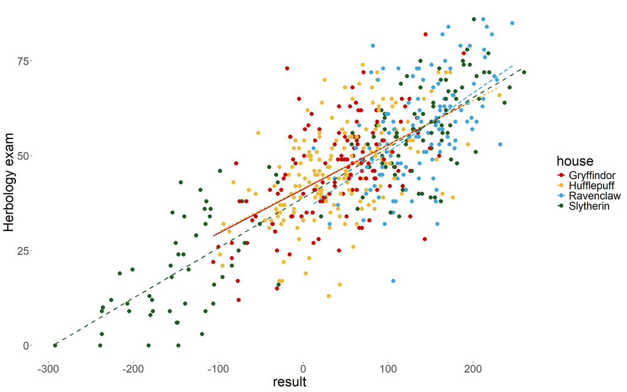

```r
scatterShapeCourse_4 <- hogwarts |>
  ggplot()+
  geom_point(aes(x = `result`,
                 y = `Herbology exam`,
                 shape = house,
                 colour = house),
             size = 5)+
  scale_color_manual(values = c("Gryffindor" = "#C50000",
                                 "Hufflepuff" = "#ECB939",
                                 "Ravenclaw" = "#41A6D9",
                                 "Slytherin" = "#1F5D25")) +
  scale_shape_manual(values = rep(20, 4))+
  scale_y_continuous(position = "left")+
  theme_custom
scatterShapeCourse_4+
  geom_smooth(aes(x = `result`,
                  y = `Herbology exam`,
                  colour = house,
                  linetype = house),
              se = FALSE,
              method = "lm")
```

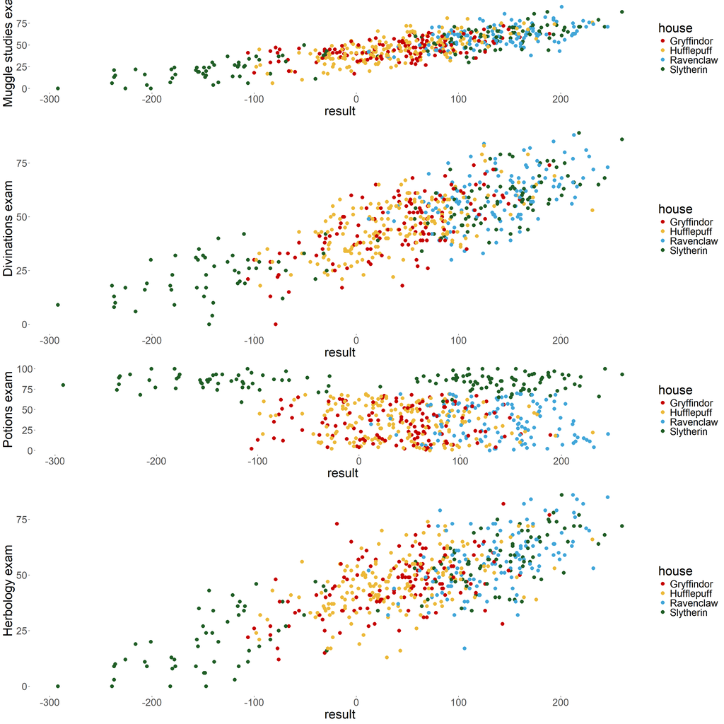

```r
ggarrange(plotlist = list(scatterShapeCourse_1, scatterShapeCourse_2, scatterShapeCourse_3, scatterShapeCourse_4),
          nrow = 4,
          heights = c(1,2))
```

Задание 3. Видоизмените график, полученный на предыдущем шаге. Сгруппируйте и покрасьте линии тренда в соответствии с одной из категориальных переменных (с такой, которая подсвечивает одно из наблюдений на предыдущем этапе, относящееся ко всем 4-м экзаменам). Постарайтесь избежать коллизий в легенде, при этом сохранив и цветовую палитру для раскраски точек по факультетам.

К сожалению, я не очень поняла второе задание, поэтому наделала много графиком, в надежде, что какой-то окажется правильным. Третье задание вытекает из второго. Я не понимаю, что нужно сделать.

#geom_col и вещи вокруг него ## Задание №1

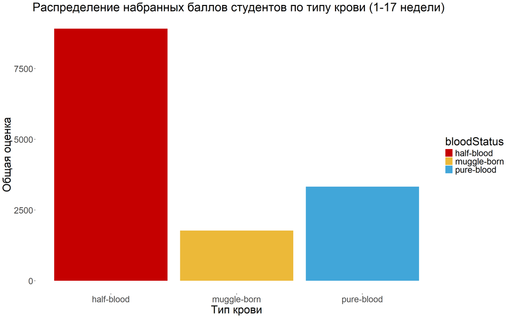

```r
hogwarts_long <- hogwarts %>%
  pivot_longer(cols = starts_with("week_"),
               names_to = "week",
               values_to = "points")

bloodStatusResult <- hogwarts_long |>
  filter(week %in% paste0("week_", 1:17)) |>
  group_by(bloodStatus) |>
  summarise(totalPoints = sum(points, na.rm = TRUE))

ggplot(bloodStatusResult) +
  geom_col(aes(x = bloodStatus,
               y = totalPoints,
               fill = bloodStatus)) +
  scale_fill_manual(values = c("half-blood" = "#C50000",
                                "muggle-born" = "#ECB939",
                                "pure-blood" = "#41A6D9")) +
  labs(x = "Тип крови",
       y = "Общая оценка",
       title = "Распределение набранных баллов студентов по типу крови (1-17 недели)") +
  theme_custom
```

Гипотеза: я не смотрела этот фильм, поэтому могу только предположить:1. у полукровок самая большая общая оценка за 17 недель потому что их бОльшее количество, чем всех остальных студентов. 2. Или возможно они обладают какими-то талантами, но они не так выражены как у чистокровок, поэтому полукровки стараются больше в учебе (так сказать, пытаются компенсировать свою нечистокровность). Маглорожденные - менее талантливы или неволшебные (как-то так, наверное), поэтому в школу волшебников попадает очень мало студентов и они не могут конкурировать в таланте и учебе с другими студентами. Чистокровки - это что-то типа “золотой молодежи” или “мажеров” их немного и они не стараются учиться, у них и так “жизнь удалась”, они решают совершенно другие проблемы, им не до учебы.

## Задание №2

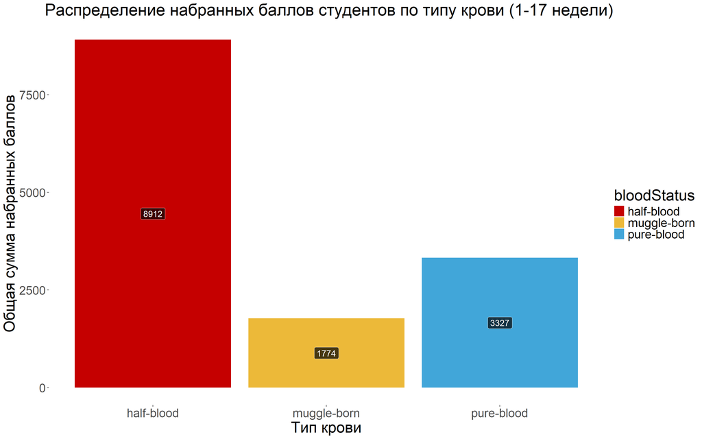

```r
# Подготовка данных
hogwarts_long <- hogwarts %>%
  pivot_longer(cols = starts_with("week_"),
               names_to = "week",
               values_to = "points")

bloodStatusResult <- hogwarts_long |>
  filter(week %in% paste0("week_", 1:17)) |>
  group_by(bloodStatus) |>
  summarise(totalPoints = sum(points, na.rm = TRUE), .groups = "drop") |> #
  arrange(desc(totalPoints))

# График
ggplot(bloodStatusResult) +
  geom_col(aes(x = bloodStatus,
               y = totalPoints,
               fill = bloodStatus)) +
  scale_fill_manual(values = c("half-blood" = "#C50000",
                                "muggle-born" = "#ECB939",
                                "pure-blood" = "#41A6D9")) +
  labs(x = "Тип крови",
       y = "Общая сумма набранных баллов", # Обновлено название оси
       title = "Распределение набранных баллов студентов по типу крови (1-17 недели)") +
  geom_label(aes(x = bloodStatus, y = totalPoints, label = totalPoints),
             position = position_stack(vjust = 0.5), # Центрирование меток по высоте столбиков
             color = "white",
             size = 5,
             fill = "black",
             alpha = 0.7) +
  theme_custom
```

Соотносится ли интерпретация с вашей гипотезой из пункта 1? Частично - Да(о количестве студентов).

## Задание №3

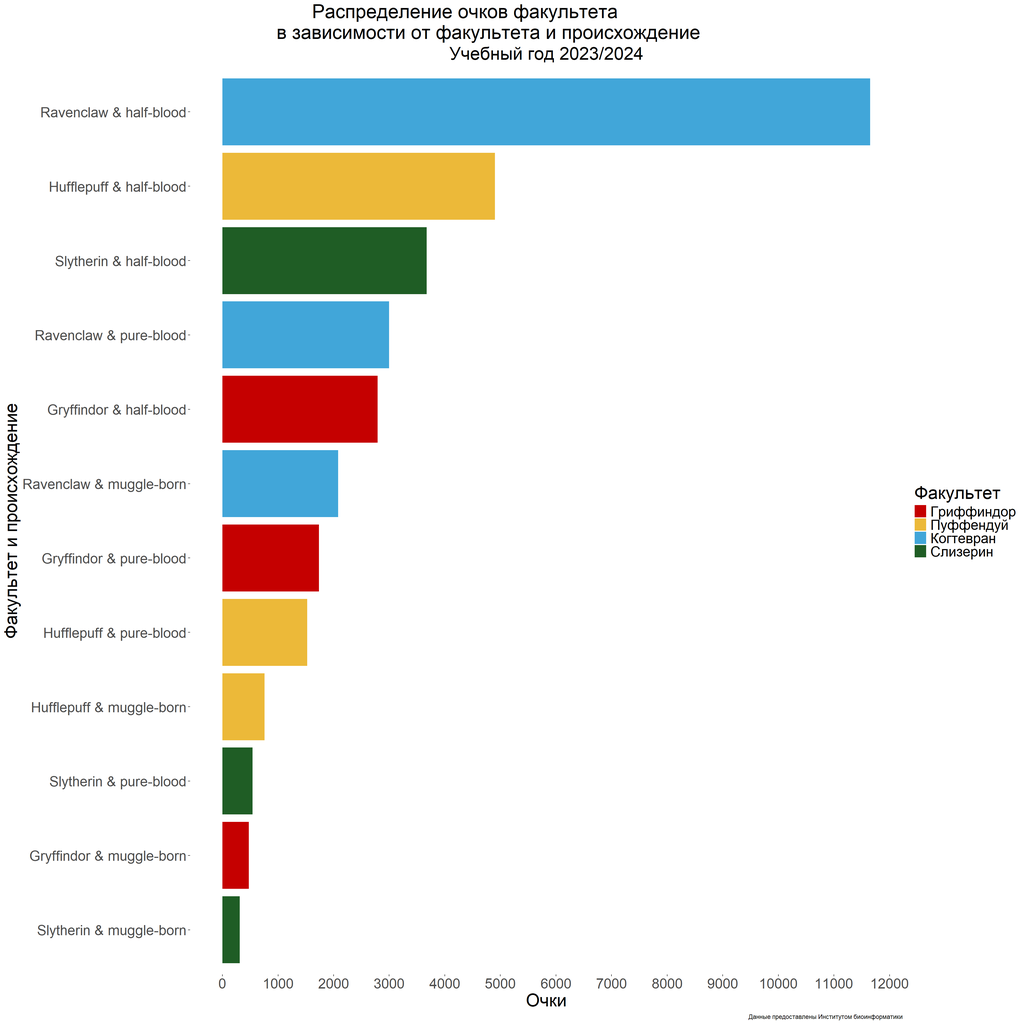

```r
hogwarts_long <- hogwarts %>%
  pivot_longer(cols = starts_with("week_"),
               names_to = "week",
               values_to = "points")

bloodStatusResult <- hogwarts_long |>
  filter(week %in% paste0("week_", 1:17)) |>
  group_by(bloodStatus, sex) |>
  summarise(totalPoints = sum(points, na.rm = TRUE))


houseResult <- hogwarts |>
  group_by(house, bloodStatus) |>
  summarise(houseTotalPoints = sum(result)) |>
  mutate(`house and bloodStatus` = paste0(house, " & ", bloodStatus))

house_wand_result_plot <- ggplot(houseResult)+
  geom_col(aes(y = fct_reorder(`house and bloodStatus`, houseTotalPoints, .desc = FALSE),
               x = houseTotalPoints,
               fill = house))+
  labs(title = "Распределение очков факультета\nв зависимости от факультета и происхождение",
       subtitle = "Учебный год 2023/2024",
       caption = "Данные предоставлены Институтом биоинформатики",
       x = "Очки",
       y = "Факультет и происхождение",
       fill = "Факультет")+
  scale_fill_manual(labels = c("Gryffindor" = "Гриффиндор",
                             "Hufflepuff" = "Пуффендуй",
                             "Ravenclaw" = "Когтевран",
                             "Slytherin" = "Слизерин"),
                    values = c("Gryffindor" = "#C50000",
                             "Hufflepuff" = "#ECB939",
                             "Ravenclaw" = "#41A6D9",
                             "Slytherin" = "#1F5D25")
                    )+
  scale_x_continuous(breaks = seq(0,12000,1000))+
  theme_custom

house_wand_result_plot
```

```r
# Сохраним график
ggsave("houseAndWandSumPoints.png", house_wand_result_plot, width = 20, height = 16, dpi = 300, units = "in")
```

Соотносится ли интерпретация с вашей гипотезой из пункта 1? Частично - Да(о количестве студентов).

## Задание №4

Изучите функцию coord_flip() . Как вы думаете, когда она может быть полезна? Как вы думаете, в чем ее плюсы и минусы? Функция coord_flip() в ggplot2 используется для поворота координат т.е. она меняет местами оси x и y. Бывает полезна, если нужно быстро перевернуть график. Но, как я поняла, строить дальнейший код с функцией coord_flip() не рекомендуется. т.к. эта функция только внешне приебразует график (не меняет оси в действительности), и это нужно держать в голове, иначе можно запутаться в своем коде и далее не правильно.

#Разное ## Задание #1

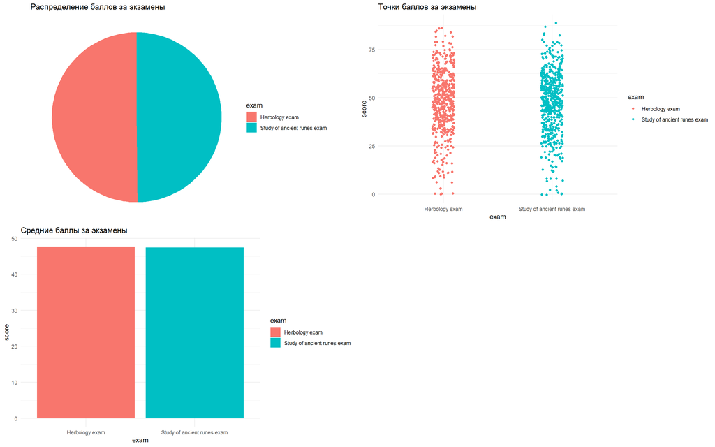

```r
data_long <- hogwarts %>%
  select(`Herbology exam`, `Study of ancient runes exam`) %>%
  pivot_longer(cols = everything(), names_to = "exam", values_to = "score")


pie_data <- data_long %>%
  group_by(exam) %>%
  summarise(total_score = sum(score))

pie_chart <- ggplot(pie_data, aes(x = "", y = total_score, fill = exam)) +
  geom_bar(stat = "identity", width = 1) +
  coord_polar("y") +
  labs(title = "Распределение баллов за экзамены") +
  theme_void()


point_chart <- ggplot(data_long, aes(x = exam, y = score, color = exam)) +
  geom_point(position = position_jitter(width = 0.1)) +
  labs(title = "Точки баллов за экзамены") +
  theme_minimal()


bar_chart <- ggplot(data_long, aes(x = exam, y = score, fill = exam)) +
  geom_bar(stat = "summary", fun = "mean") +
  labs(title = "Средние баллы за экзамены") +
  theme_minimal()

# все графики
grid.arrange(pie_chart, point_chart, bar_chart, nrow = 2, ncol = 2,
             layout_matrix = rbind(c(1, 2), c(3, NA)))
```

##Задание №2

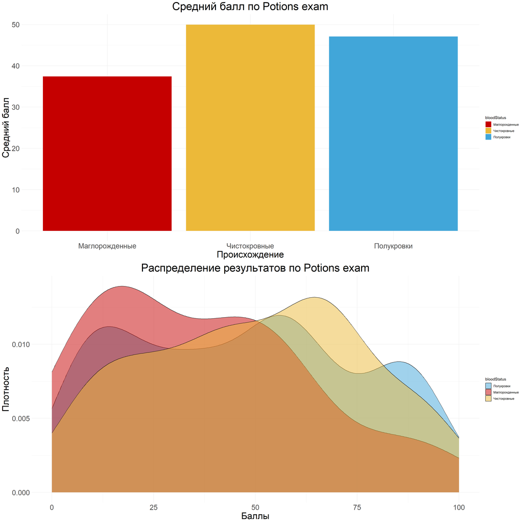

```r
hogwarts$bloodStatus <- recode(hogwarts$bloodStatus,
                                `muggle-born` = "Маглорожденные",
                                `pure-blood` = "Чистокровные",
                                `half-blood` = "Полукровки")

average_scores <- hogwarts %>%
  group_by(bloodStatus) %>%
  summarise(mean_score = mean(`Potions exam`, na.rm = TRUE))


average_scores$bloodStatus <- factor(average_scores$bloodStatus,
                                      levels = c("Маглорожденные", "Чистокровные", "Полукровки"))


p1 <- ggplot(average_scores, aes(x = bloodStatus, y = mean_score, fill = bloodStatus)) +
  geom_bar(stat = "identity") +
  labs(title = "Средний балл по Potions exam",
       x = "Происхождение",
       y = "Средний балл") +
  scale_fill_manual(values = c("Маглорожденные" = "#C50000",
                                "Чистокровные" = "#ECB939",
                                "Полукровки" = "#41A6D9")) +
  theme_minimal() +
  theme(plot.title = element_text(size = 30, hjust = 0.5),
        axis.text = element_text(size = 20),
        axis.title = element_text(size = 25))

p2 <- ggplot(hogwarts, aes(x = `Potions exam`, fill = bloodStatus)) +
  geom_density(alpha = 0.5) +
  labs(title = "Распределение результатов по Potions exam",
       x = "Баллы",
       y = "Плотность") +
  scale_fill_manual(values = c("Маглорожденные" = "#C50000",
                                "Чистокровные" = "#ECB939",
                                "Полукровки" = "#41A6D9")) +
  theme_minimal() +
  theme(plot.title = element_text(size = 30, hjust = 0.5),
        axis.text = element_text(size = 20),
        axis.title = element_text(size = 25))
ggarrange(p1, p2, ncol = 1, nrow = 2)
```

#Воспроизведение графика

[figure not shown]

```r
hogwarts$house <- recode(hogwarts$house,
                         Gryffindor = "Гриффиндор",
                         Hufflepuff = "Пуффендуй",
                         Ravenclaw = "Когтевран",
                         Slytherin = "Слизерин")


colors <- c("Гриффиндор" = "#C50000",
            "Пуффендуй" = "#ECB939",
            "Когтевран" = "#41A6D9",
            "Слизерин" = "#1F5D25")


ggplot(hogwarts, aes(x = sex, y = result, fill = house)) +
  geom_violin(trim = FALSE) +
  geom_hline(yintercept = 0, linetype = "dashed", color = "red") +
  scale_fill_manual(values = colors) +
  labs(title = "Баллы студентов Хогвардса",
       subtitle = "Распределение числа баллов у студентов различных факультетов Хогвардса в 2023-2024 учебном году",
       x = "Пол",
       y = "Количество очков") +
  scale_y_continuous(limits = c(-300, 300)) +  # Установка пределов для оси Y
  theme_minimal() +
  theme(plot.title = element_text(size = 30, hjust = 0.5),
        plot.subtitle = element_text(size = 20, hjust = 0.5),
        legend.title = element_text(size = 25),
        legend.text = element_text(size = 20),
        axis.text = element_text(size = 20),
        axis.title = element_text(size = 25))
```